# Intro to R Markdown

14 May 2018

## The problem is the process

The Excel-Word approach is looooong and error-prone. Exaggerated example:

1. Receive non-machine-readable data in Excel format
2. Use a pre-prepared Excel template to reformat the data
3. Generate figures, tables and plots
4. Copy and paste to ~100-page Word document
5. Find error/need to alter something
6. Fix it
7. Spend ages re-copy-pasting the updated bits
8. Get confused about the current working version
9. Repeat steps 5 to 7 until 4am

## Minimise the risk

We can reduce human error and go faster with R.

1. Receive machine-readable data in Excel format
2. Run a pre-prepared R Markdown file
3. Make minor tweaks if needed and re-render stress-free
4. Use the saved time to prepare more informative commentary and have a cup of tea

## R Markdown is the answer

- Write plain text in a .Rmd file
- 'Mark up' with symbols (`*`, `[]`, `^`, etc)
- Embed your R code
- Render to an output HTML, Word or PDF document

.Rmd ➡️ `knitr` ➡️ .md ➡️ `pandoc` ➡️ .html/.pdf/.docx

In RStudio: Help > Cheatsheets for hints and tips.

## R Markdown formatting

You type:

```
*Italic*, **bold** super^script^ and a [link](www.gov.uk).
```

You get:

> *Italic*, **bold**, super<sup>script</sup> and a link.

## Inline code

You can write some R code in the middle of a sentence!

Wrap the code in backticks (the button under the Esc key) and start it with the letter `r`.

You type:

```r
The answer to 1 + 1 is `r 1 + 1`
```

You get:

> The answer to 1 + 1 is 2

## Inline code

Let's say `my_value <- "Lotad"`

You type:

```r
The best Pokemon is `r my_value`
```

You get:

> The best Pokemon is Lotad

## Code chunks

You type:

````
Here's an important plot of chick weights and feed types.

```{r chicks}
chickwts %>%
  group_by(feed) %>%
  ggplot() +
  geom_col(aes(x = feed, y = weight))
```
````

## Code chunks

You get:

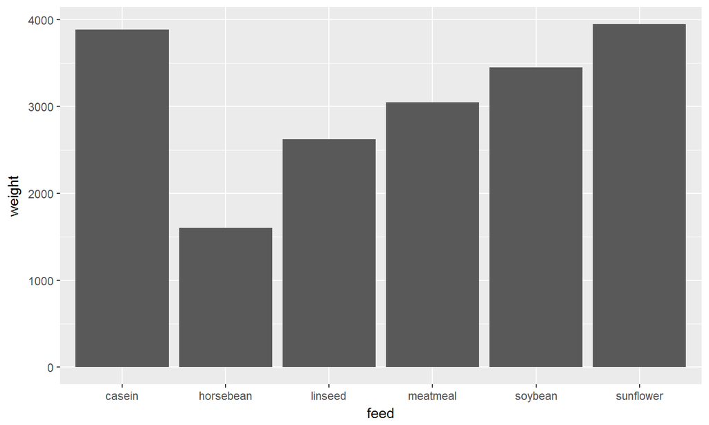

## How to

1. In RStudio: File > New File > R Markdown
2. Write your text and embed your code
3. Click 'Knit' to render the document
4. It outputs to your working directory